# Unsupervised-Assignment

*PART - A*

1.Data Understanding & Exploration:

A.Read ‘Car name.csv’ as a DataFrame and assign it to a variable.

B.Read ‘Car-Attributes.json as a DataFrame and assign it to a variable.

C.Merge both the DataFrames together to form a single DataFrame.

D.Print 5 point summary of the numerical features and share insights.

```python
import numpy as np
import pandas as pd
import seaborn as sns
import matplotlib.pyplot as plt
%matplotlib inline
from scipy.stats import zscore
from sklearn.cluster import KMeans
from sklearn.metrics import silhouette_score, mean_squared_error, r2_score, accuracy_score, f1_score, precision_score ,recall_score, roc_auc_score
from sklearn.cluster import AgglomerativeClustering
from scipy.spatial.distance import cdist
```

```python
car = pd.read_csv("Car.csv")
carAttributes = pd.read_json("Car-Attributes.json")
```

```python
car.head()
```

|  | car_name |
| --- | --- |
| 0 | chevrolet chevelle malibu |
| 1 | buick skylark 320 |
| 2 | plymouth satellite |
| 3 | amc rebel sst |
| 4 | ford torino |

```python
carAttributes.head()
```

|  | acc | cyl | disp | hp | mpg | origin | wt | yr |
| --- | --- | --- | --- | --- | --- | --- | --- | --- |
| 0 | 12.0 | 8 | 307.0 | 130 | 18.0 | 1 | 3504 | 70 |
| 1 | 11.5 | 8 | 350.0 | 165 | 15.0 | 1 | 3693 | 70 |
| 2 | 11.0 | 8 | 318.0 | 150 | 18.0 | 1 | 3436 | 70 |
| 3 | 12.0 | 8 | 304.0 | 150 | 16.0 | 1 | 3433 | 70 |
| 4 | 10.5 | 8 | 302.0 | 140 | 17.0 | 1 | 3449 | 70 |

```python
df = car.join(carAttributes)
df.head()
```

|  | car_name | acc | cyl | disp | hp | mpg | origin | wt | yr |
| --- | --- | --- | --- | --- | --- | --- | --- | --- | --- |
| 0 | chevrolet chevelle malibu | 12.0 | 8 | 307.0 | 130 | 18.0 | 1 | 3504 | 70 |
| 1 | buick skylark 320 | 11.5 | 8 | 350.0 | 165 | 15.0 | 1 | 3693 | 70 |
| 2 | plymouth satellite | 11.0 | 8 | 318.0 | 150 | 18.0 | 1 | 3436 | 70 |
| 3 | amc rebel sst | 12.0 | 8 | 304.0 | 150 | 16.0 | 1 | 3433 | 70 |
| 4 | ford torino | 10.5 | 8 | 302.0 | 140 | 17.0 | 1 | 3449 | 70 |

```python
df.describe()
```

|  | acc | cyl | disp | mpg | origin | wt | yr |
| --- | --- | --- | --- | --- | --- | --- | --- |
| count | 398.000000 | 398.000000 | 398.000000 | 398.000000 | 398.000000 | 398.000000 | 398.000000 |
| mean | 15.568090 | 5.454774 | 193.425879 | 23.514573 | 1.572864 | 2970.424623 | 76.010050 |
| std | 2.757689 | 1.701004 | 104.269838 | 7.815984 | 0.802055 | 846.841774 | 3.697627 |
| min | 8.000000 | 3.000000 | 68.000000 | 9.000000 | 1.000000 | 1613.000000 | 70.000000 |
| 25% | 13.825000 | 4.000000 | 104.250000 | 17.500000 | 1.000000 | 2223.750000 | 73.000000 |
| 50% | 15.500000 | 4.000000 | 148.500000 | 23.000000 | 1.000000 | 2803.500000 | 76.000000 |
| 75% | 17.175000 | 8.000000 | 262.000000 | 29.000000 | 2.000000 | 3608.000000 | 79.000000 |
| max | 24.800000 | 8.000000 | 455.000000 | 46.600000 | 3.000000 | 5140.000000 | 82.000000 |

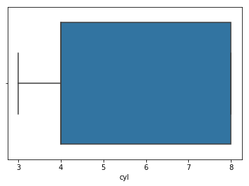

```python
sns.boxplot(df.cyl)
```

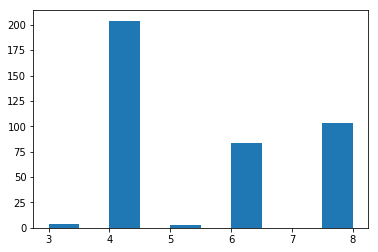

```python
plt.hist(df.cyl)
```

acc: distribution seems to be normal with mean and median are close to 15.5, third quantile is at 17.17 and max is 24.8, suggesting there are outliers present.

disp: right skewed distribution,no outliers.

mpg: right skewed distribution, outlier present.

wt:right skewed distribution, no outlier.

2.Data Preparation & Analysis:

A.Check and print feature-wise percentage of missing values present in the data and impute with the best suitable approach.

B.Check for duplicate values in the data and impute with the best suitable approach.

C.Plot a pairplot for all features.

D.Visualize a scatterplot for ‘wt’ and ‘disp’. Datapoints should be distinguishable by ‘cyl’.

E.Share insights for Q2.d.

F.Visualize a scatterplot for ‘wt’ and ’mpg’. Datapoints should be distinguishable by ‘cyl’.

G.Share insights for Q2.f.

H.Check for unexpected values in all the features and datapoints with such values. [Hint: ‘?’ is present in ‘hp’]

```python
df.info()
```

```
<class 'pandas.core.frame.DataFrame'>
RangeIndex: 398 entries, 0 to 397
Data columns (total 9 columns):
car_name    398 non-null object
acc         398 non-null float64
cyl         398 non-null int64
disp        398 non-null float64
hp          398 non-null object
mpg         398 non-null float64
origin      398 non-null int64
wt          398 non-null int64
yr          398 non-null int64
dtypes: float64(3), int64(4), object(2)
memory usage: 28.1+ KB
```

Note : No null values, but hp's data type is object suggesting some missing values as it should be numeric and continuous.

```python
#Analyse hp further
print(df.hp.unique())
#print(df.hp.value_counts())
```

```
[130 165 150 140 198 220 215 225 190 170 160 95 97 85 88 46 87 90 113 200
 210 193 '?' 100 105 175 153 180 110 72 86 70 76 65 69 60 80 54 208 155
 112 92 145 137 158 167 94 107 230 49 75 91 122 67 83 78 52 61 93 148 129
 96 71 98 115 53 81 79 120 152 102 108 68 58 149 89 63 48 66 139 103 125
 133 138 135 142 77 62 132 84 64 74 116 82]
```

```python
df.hp = df.hp.replace('?', np.nan)
print(df.hp.median())
df.hp = df.hp.replace(np.nan, 93.5)
print(df.hp.unique())
```

```
93.5
[130.  165.  150.  140.  198.  220.  215.  225.  190.  170.  160.   95.
  97.   85.   88.   46.   87.   90.  113.  200.  210.  193.   93.5 100.
 105.  175.  153.  180.  110.   72.   86.   70.   76.   65.   69.   60.
  80.   54.  208.  155.  112.   92.  145.  137.  158.  167.   94.  107.
 230.   49.   75.   91.  122.   67.   83.   78.   52.   61.   93.  148.
 129.   96.   71.   98.  115.   53.   81.   79.  120.  152.  102.  108.
  68.   58.  149.   89.   63.   48.   66.  139.  103.  125.  133.  138.
 135.  142.   77.   62.  132.   84.   64.   74.  116.   82. ]
```

```python
df.describe()
```

|  | acc | cyl | disp | hp | mpg | origin | wt | yr |
| --- | --- | --- | --- | --- | --- | --- | --- | --- |
| count | 398.000000 | 398.000000 | 398.000000 | 398.000000 | 398.000000 | 398.000000 | 398.000000 | 398.000000 |
| mean | 15.568090 | 5.454774 | 193.425879 | 104.304020 | 23.514573 | 1.572864 | 2970.424623 | 76.010050 |
| std | 2.757689 | 1.701004 | 104.269838 | 38.222625 | 7.815984 | 0.802055 | 846.841774 | 3.697627 |
| min | 8.000000 | 3.000000 | 68.000000 | 46.000000 | 9.000000 | 1.000000 | 1613.000000 | 70.000000 |
| 25% | 13.825000 | 4.000000 | 104.250000 | 76.000000 | 17.500000 | 1.000000 | 2223.750000 | 73.000000 |
| 50% | 15.500000 | 4.000000 | 148.500000 | 93.500000 | 23.000000 | 1.000000 | 2803.500000 | 76.000000 |
| 75% | 17.175000 | 8.000000 | 262.000000 | 125.000000 | 29.000000 | 2.000000 | 3608.000000 | 79.000000 |
| max | 24.800000 | 8.000000 | 455.000000 | 230.000000 | 46.600000 | 3.000000 | 5140.000000 | 82.000000 |

```python
df.info()
```

```
<class 'pandas.core.frame.DataFrame'>
RangeIndex: 398 entries, 0 to 397
Data columns (total 9 columns):
car_name    398 non-null object
acc         398 non-null float64
cyl         398 non-null int64
disp        398 non-null float64
hp          398 non-null float64
mpg         398 non-null float64
origin      398 non-null int64
wt          398 non-null int64
yr          398 non-null int64
dtypes: float64(4), int64(4), object(1)
memory usage: 28.1+ KB
```

```python
df.isnull().sum()
```

```
car_name    0
acc         0
cyl         0
disp        0
hp          0
mpg         0
origin      0
wt          0
yr          0
dtype: int64
```

```python
#Dropping car name column
finalDf =  df.drop('car_name', axis=1)
finalDf.head(2)
```

|  | acc | cyl | disp | hp | mpg | origin | wt | yr |
| --- | --- | --- | --- | --- | --- | --- | --- | --- |
| 0 | 12.0 | 8 | 307.0 | 130.0 | 18.0 | 1 | 3504 | 70 |
| 1 | 11.5 | 8 | 350.0 | 165.0 | 15.0 | 1 | 3693 | 70 |

```python
bool_series = df.duplicated()
bool_series.unique()
```

```
array([False])
```

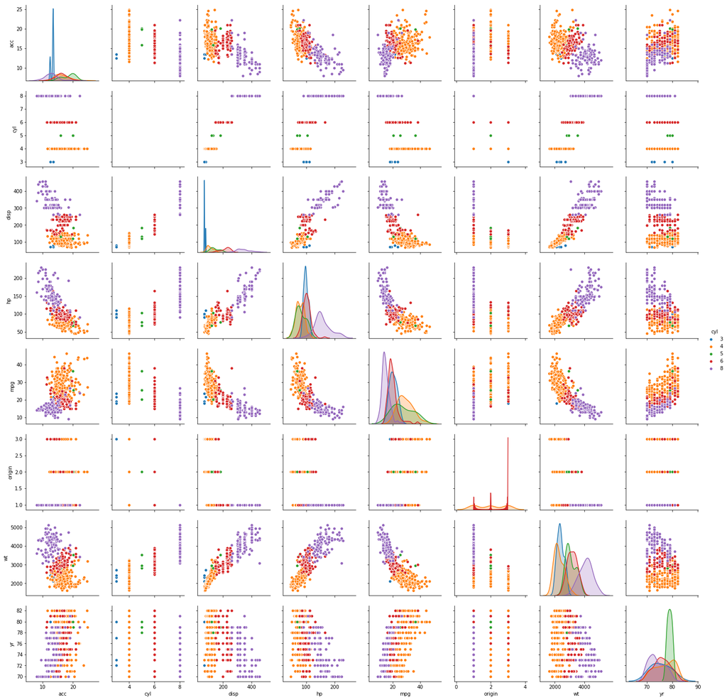

```python
sns.pairplot(finalDf, diag_kind='kde',hue='cyl')
```

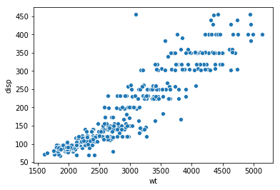

```python
sns.scatterplot(finalDf.wt,finalDf.disp)
```

```python
print('Correlation between wt and disp is',round(finalDf.wt.corr(finalDf.disp),2))
```

```
Correlation between wt and disp is 0.93
```

Shows strong correlation b/w wt and disp of 0.93.

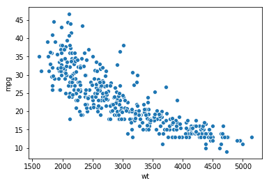

```python
sns.scatterplot(finalDf.wt,finalDf.mpg)
```

```python
print('Correlation between wt and mpg is',round(finalDf.wt.corr(finalDf.mpg),2))
```

```
Correlation between wt and mpg is -0.83
```

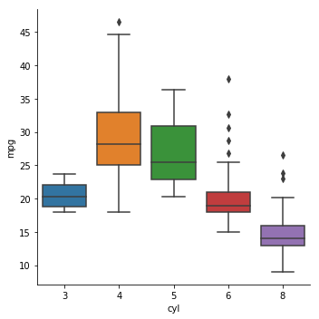

```python
sns.catplot(x="cyl", y="mpg", kind="box", data=finalDf)
```

Car with 4 cyl is providing best mpg.

3.Clustering:

A.Apply K-Means clustering for 2 to 10 clusters.

B.Plot a visual and find elbow point.

C.On the above visual, highlight which are the possible Elbow points.

D.Train a K-means clustering model once again on the optimal number of clusters.

E.Add a new feature in the DataFrame which will have labels based upon cluster value.

F.Plot a visual and color the datapoints based upon clusters.

G.Pass a new DataPoint and predict which cluster it belongs to.

```python
#Scaling due to wt.
dfScaled = finalDf.iloc[:,1:7].apply(zscore)
dfScaled.head()
```

|  | cyl | disp | hp | mpg | origin | wt |
| --- | --- | --- | --- | --- | --- | --- |
| 0 | 1.498191 | 1.090604 | 0.673118 | -0.706439 | -0.715145 | 0.630870 |
| 1 | 1.498191 | 1.503514 | 1.589958 | -1.090751 | -0.715145 | 0.854333 |
| 2 | 1.498191 | 1.196232 | 1.197027 | -0.706439 | -0.715145 | 0.550470 |
| 3 | 1.498191 | 1.061796 | 1.197027 | -0.962647 | -0.715145 | 0.546923 |
| 4 | 1.498191 | 1.042591 | 0.935072 | -0.834543 | -0.715145 | 0.565841 |

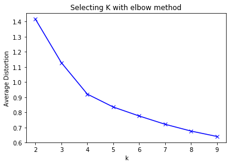

```python
clusters = range(2,10)
meanDistortions = []

for k in clusters:
    model = KMeans(n_clusters = k)
    model.fit(dfScaled)
    prediction = model.predict(dfScaled)
    meanDistortions.append(sum(np.min(cdist(dfScaled, model.cluster_centers_, 'euclidean'), axis = 1))/dfScaled.shape[0])

plt.plot(clusters, meanDistortions, 'bx-')
plt.xlabel('k')
plt.ylabel('Average Distortion')
plt.title('Selecting K with elbow method');
```

Taking k = 2 for now

```python
final_model = KMeans(2)
final_model.fit(dfScaled)
prediction = final_model.predict(dfScaled)

df['GROUP'] = prediction
dfScaled['GROUP'] = prediction
print("Groups Assigned: \n")
df.head()
```

```
Groups Assigned:
```

|  | car_name | acc | cyl | disp | hp | mpg | origin | wt | yr | GROUP |
| --- | --- | --- | --- | --- | --- | --- | --- | --- | --- | --- |
| 0 | chevrolet chevelle malibu | 12.0 | 8 | 307.0 | 130.0 | 18.0 | 1 | 3504 | 70 | 1 |
| 1 | buick skylark 320 | 11.5 | 8 | 350.0 | 165.0 | 15.0 | 1 | 3693 | 70 | 1 |
| 2 | plymouth satellite | 11.0 | 8 | 318.0 | 150.0 | 18.0 | 1 | 3436 | 70 | 1 |
| 3 | amc rebel sst | 12.0 | 8 | 304.0 | 150.0 | 16.0 | 1 | 3433 | 70 | 1 |
| 4 | ford torino | 10.5 | 8 | 302.0 | 140.0 | 17.0 | 1 | 3449 | 70 | 1 |

[output not shown]

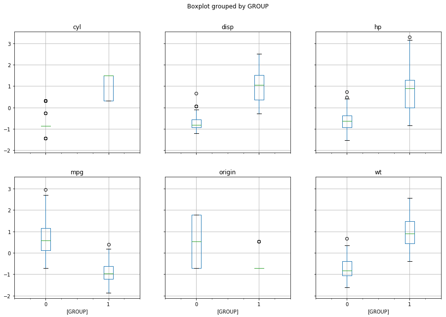

```python
dfScaled.boxplot(by='GROUP', layout = (2,3),figsize=(15,10))
```

```python
carClust = dfScaled.groupby(['GROUP'])
carClust.mean()
```

| GROUP | cyl | disp | hp | mpg | origin | wt |
| --- | --- | --- | --- | --- | --- | --- |
| 0 | -0.780789 | -0.763564 | -0.617124 | 0.681676 | 0.527698 | -0.729015 |
| 1 | 1.025920 | 1.003287 | 0.810872 | -0.895690 | -0.693371 | 0.957891 |

trying clustering with K=4, as indicated by next elbow point

```python
final_model=KMeans(4)
final_model.fit(dfScaled)
prediction=final_model.predict(dfScaled)

#Append the prediction
dfScaled["GROUP"] = prediction
df["GROUP"] = prediction
print("Groups Assigned : \n")
dfScaled.head()
```

```
Groups Assigned :
```

|  | cyl | disp | hp | mpg | origin | wt | GROUP |
| --- | --- | --- | --- | --- | --- | --- | --- |
| 0 | 1.498191 | 1.090604 | 0.673118 | -0.706439 | -0.715145 | 0.630870 | 1 |
| 1 | 1.498191 | 1.503514 | 1.589958 | -1.090751 | -0.715145 | 0.854333 | 1 |
| 2 | 1.498191 | 1.196232 | 1.197027 | -0.706439 | -0.715145 | 0.550470 | 1 |
| 3 | 1.498191 | 1.061796 | 1.197027 | -0.962647 | -0.715145 | 0.546923 | 1 |
| 4 | 1.498191 | 1.042591 | 0.935072 | -0.834543 | -0.715145 | 0.565841 | 1 |

```python
carClust = dfScaled.groupby(['GROUP'])
carClust.mean()
```

| GROUP | cyl | disp | hp | mpg | origin | wt |
| --- | --- | --- | --- | --- | --- | --- |
| 0 | -0.808160 | -0.896780 | -0.729768 | 0.993268 | 1.429776 | -0.938101 |
| 1 | 1.498191 | 1.496288 | 1.495439 | -1.144105 | -0.715145 | 1.393080 |
| 2 | -0.803291 | -0.662471 | -0.521843 | 0.411759 | -0.310269 | -0.539651 |
| 3 | 0.409230 | 0.338002 | -0.085732 | -0.549832 | -0.668331 | 0.349546 |

# K=2

# K=4

*Part - B*

1.Data Understanding & Cleaning:

A.Read ‘vehicle.csv’ and save as DataFrame.

B.Check percentage of missing values and impute with correct approach.

C.Visualize a Pie-chart and print percentage of values for variable ‘class’.

D.Check for duplicate rows in the data and impute with correct approach.

```python
vehicle = pd.read_csv("vehicle.csv")
vehicle.head()
```

|  | compactness | circularity | distance_circularity | radius_ratio | pr.axis_aspect_ratio | max.length_aspect_ratio | scatter_ratio | elongatedness | pr.axis_rectangularity | max.length_rectangularity | scaled_variance | scaled_variance.1 | scaled_radius_of_gyration | scaled_radius_of_gyration.1 | skewness_about | skewness_about.1 | skewness_about.2 | hollows_ratio | class |
| --- | --- | --- | --- | --- | --- | --- | --- | --- | --- | --- | --- | --- | --- | --- | --- | --- | --- | --- | --- |
| 0 | 95 | 48.0 | 83.0 | 178.0 | 72.0 | 10 | 162.0 | 42.0 | 20.0 | 159 | 176.0 | 379.0 | 184.0 | 70.0 | 6.0 | 16.0 | 187.0 | 197 | van |
| 1 | 91 | 41.0 | 84.0 | 141.0 | 57.0 | 9 | 149.0 | 45.0 | 19.0 | 143 | 170.0 | 330.0 | 158.0 | 72.0 | 9.0 | 14.0 | 189.0 | 199 | van |
| 2 | 104 | 50.0 | 106.0 | 209.0 | 66.0 | 10 | 207.0 | 32.0 | 23.0 | 158 | 223.0 | 635.0 | 220.0 | 73.0 | 14.0 | 9.0 | 188.0 | 196 | car |
| 3 | 93 | 41.0 | 82.0 | 159.0 | 63.0 | 9 | 144.0 | 46.0 | 19.0 | 143 | 160.0 | 309.0 | 127.0 | 63.0 | 6.0 | 10.0 | 199.0 | 207 | van |
| 4 | 85 | 44.0 | 70.0 | 205.0 | 103.0 | 52 | 149.0 | 45.0 | 19.0 | 144 | 241.0 | 325.0 | 188.0 | 127.0 | 9.0 | 11.0 | 180.0 | 183 | bus |

```python
vehicle.info()
```

```
<class 'pandas.core.frame.DataFrame'>
RangeIndex: 846 entries, 0 to 845
Data columns (total 19 columns):
compactness                    846 non-null int64
circularity                    841 non-null float64
distance_circularity           842 non-null float64
radius_ratio                   840 non-null float64
pr.axis_aspect_ratio           844 non-null float64
max.length_aspect_ratio        846 non-null int64
scatter_ratio                  845 non-null float64
elongatedness                  845 non-null float64
pr.axis_rectangularity         843 non-null float64
max.length_rectangularity      846 non-null int64
scaled_variance                843 non-null float64
scaled_variance.1              844 non-null float64
scaled_radius_of_gyration      844 non-null float64
scaled_radius_of_gyration.1    842 non-null float64
skewness_about                 840 non-null float64
skewness_about.1               845 non-null float64
skewness_about.2               845 non-null float64
hollows_ratio                  846 non-null int64
class                          846 non-null object
dtypes: float64(14), int64(4), object(1)
memory usage: 125.7+ KB
```

```python
#Null counts:
vehicle.isnull().sum()
```

```
compactness                    0
circularity                    5
distance_circularity           4
radius_ratio                   6
pr.axis_aspect_ratio           2
max.length_aspect_ratio        0
scatter_ratio                  1
elongatedness                  1
pr.axis_rectangularity         3
max.length_rectangularity      0
scaled_variance                3
scaled_variance.1              2
scaled_radius_of_gyration      2
scaled_radius_of_gyration.1    4
skewness_about                 6
skewness_about.1               1
skewness_about.2               1
hollows_ratio                  0
class                          0
dtype: int64
```

```python
missingPercentage = vehicle.isna().sum()/len(vehicle.index) * 100
missingPercentage
```

```
compactness                    0.000000
circularity                    0.591017
distance_circularity           0.472813
radius_ratio                   0.709220
pr.axis_aspect_ratio           0.236407
max.length_aspect_ratio        0.000000
scatter_ratio                  0.118203
elongatedness                  0.118203
pr.axis_rectangularity         0.354610
max.length_rectangularity      0.000000
scaled_variance                0.354610
scaled_variance.1              0.236407
scaled_radius_of_gyration      0.236407
scaled_radius_of_gyration.1    0.472813
skewness_about                 0.709220
skewness_about.1               0.118203
skewness_about.2               0.118203
hollows_ratio                  0.000000
class                          0.000000
dtype: float64
```

```python
for i in vehicle.columns[:-1]:
    vehicle[i]=vehicle[i].replace(np.nan,vehicle[i].median())
```

```python
#Null counts:
vehicle.isna().sum()
```

```
compactness                    0
circularity                    0
distance_circularity           0
radius_ratio                   0
pr.axis_aspect_ratio           0
max.length_aspect_ratio        0
scatter_ratio                  0
elongatedness                  0
pr.axis_rectangularity         0
max.length_rectangularity      0
scaled_variance                0
scaled_variance.1              0
scaled_radius_of_gyration      0
scaled_radius_of_gyration.1    0
skewness_about                 0
skewness_about.1               0
skewness_about.2               0
hollows_ratio                  0
class                          0
dtype: int64
```

```python
vehicle["class"].unique()
```

```
array(['van', 'car', 'bus'], dtype=object)
```

```python
#Percentage
vehicle['class'].value_counts(normalize=True) * 100
```

```
car    50.709220
bus    25.768322
van    23.522459
Name: class, dtype: float64
```

[figure not shown]

```python
fig = plt.figure(figsize =(10, 7))
classP = [50.7, 25.7, 23.4]
plt.pie(classP, labels = vehicle["class"].unique())

# show plot
plt.show()
```

```python
#vehicle.boxplot(by='class', layout= (6,3), figsize=(20,30));
```

2.Data Preparation:

A.Split data into X and Y. [Train and Test optional]

B.Standardize the Data.

```python
X = vehicle.iloc[:,:-1]
y = vehicle.iloc[:,-1]
```

```python
import warnings
warnings.filterwarnings('ignore')
from scipy.stats import zscore
from sklearn.model_selection import train_test_split
from sklearn.decomposition import PCA
from sklearn.svm import SVC
from sklearn.metrics import f1_score, classification_report, confusion_matrix
```

```python
X_train, X_test, y_train, y_test = train_test_split(X,y, test_size=0.3,random_state=42)
```

```python
X_train.head()
```

|  | compactness | circularity | distance_circularity | radius_ratio | pr.axis_aspect_ratio | max.length_aspect_ratio | scatter_ratio | elongatedness | pr.axis_rectangularity | max.length_rectangularity | scaled_variance | scaled_variance.1 | scaled_radius_of_gyration | scaled_radius_of_gyration.1 | skewness_about | skewness_about.1 | skewness_about.2 | hollows_ratio |
| --- | --- | --- | --- | --- | --- | --- | --- | --- | --- | --- | --- | --- | --- | --- | --- | --- | --- | --- |
| 300 | 106 | 53.0 | 98.0 | 193.0 | 60.0 | 10 | 215.0 | 31.0 | 24.0 | 169 | 224.0 | 681.0 | 218.0 | 73.0 | 8.0 | 21.0 | 188.0 | 197 |
| 73 | 73 | 37.0 | 53.0 | 111.0 | 54.0 | 6 | 126.0 | 55.0 | 18.0 | 128 | 135.0 | 227.0 | 147.0 | 82.0 | 1.0 | 15.0 | 176.0 | 184 |
| 586 | 98 | 55.0 | 108.0 | 168.0 | 53.0 | 11 | 224.0 | 30.0 | 25.0 | 178 | 231.0 | 737.0 | 217.0 | 73.0 | 8.0 | 30.0 | 187.0 | 198 |
| 753 | 91 | 36.0 | 72.0 | 162.0 | 60.0 | 8 | 150.0 | 44.0 | 19.0 | 133 | 166.0 | 334.0 | 121.0 | 63.0 | 2.0 | 22.0 | 196.0 | 205 |
| 405 | 88 | 40.0 | 73.0 | 173.0 | 68.0 | 7 | 150.0 | 44.0 | 19.0 | 137 | 174.0 | 341.0 | 151.0 | 69.0 | 2.0 | 20.0 | 196.0 | 200 |

3.Model Building:

A.Train a base Classification model using SVM.

B.Print Classification metrics for train data.

C.Apply PCA on the data with 10 components.

D.Visualize Cumulative Variance Explained with Number of Components.

E.Draw a horizontal line on the above plot to highlight the threshold of 90%.

F.Apply PCA on the data. This time Select Minimum Components with 90% or above variance explained.

G.Train SVM model on components selected from above step.

H.Print Classification metrics for train data of above model and share insights.

```python
model = SVC(gamma=0.01, C = 10)
model.fit(X_train,y_train)
```

```
SVC(C=10, cache_size=200, class_weight=None, coef0=0.0,
  decision_function_shape='ovr', degree=3, gamma=0.01, kernel='rbf',
  max_iter=-1, probability=False, random_state=None, shrinking=True,
  tol=0.001, verbose=False)
```

```python
y_pred = model.predict(X_test)
```

```python
model.score(X_train,y_train)
```

```
1.0
```

```python
model.score(X_test,y_test)
```

```
0.5866141732283464
```

```python
print(classification_report(y_test,y_pred))
```

```
              precision    recall  f1-score   support

         bus       1.00      0.27      0.42        78
         car       0.53      1.00      0.69       118
         van       1.00      0.17      0.29        58

   micro avg       0.59      0.59      0.59       254
   macro avg       0.84      0.48      0.47       254
weighted avg       0.78      0.59      0.52       254
```

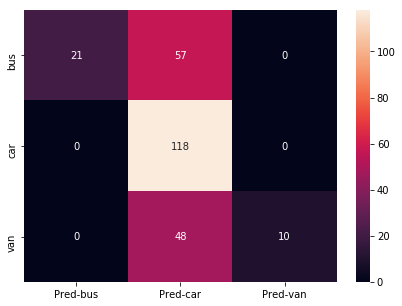

```python
cm = confusion_matrix(y_test,y_pred)

df_cm = pd.DataFrame(cm, index = ['bus','car','van'], columns = ['Pred-bus','Pred-car','Pred-van'])
plt.figure(figsize = (7,5))
sns.heatmap(df_cm ,annot=True, fmt = 'g');
```

```python
Xscaled = vehicle.iloc[:,:-1]
Xscaled.head()
```

|  | compactness | circularity | distance_circularity | radius_ratio | pr.axis_aspect_ratio | max.length_aspect_ratio | scatter_ratio | elongatedness | pr.axis_rectangularity | max.length_rectangularity | scaled_variance | scaled_variance.1 | scaled_radius_of_gyration | scaled_radius_of_gyration.1 | skewness_about | skewness_about.1 | skewness_about.2 | hollows_ratio |
| --- | --- | --- | --- | --- | --- | --- | --- | --- | --- | --- | --- | --- | --- | --- | --- | --- | --- | --- |
| 0 | 95 | 48.0 | 83.0 | 178.0 | 72.0 | 10 | 162.0 | 42.0 | 20.0 | 159 | 176.0 | 379.0 | 184.0 | 70.0 | 6.0 | 16.0 | 187.0 | 197 |
| 1 | 91 | 41.0 | 84.0 | 141.0 | 57.0 | 9 | 149.0 | 45.0 | 19.0 | 143 | 170.0 | 330.0 | 158.0 | 72.0 | 9.0 | 14.0 | 189.0 | 199 |
| 2 | 104 | 50.0 | 106.0 | 209.0 | 66.0 | 10 | 207.0 | 32.0 | 23.0 | 158 | 223.0 | 635.0 | 220.0 | 73.0 | 14.0 | 9.0 | 188.0 | 196 |
| 3 | 93 | 41.0 | 82.0 | 159.0 | 63.0 | 9 | 144.0 | 46.0 | 19.0 | 143 | 160.0 | 309.0 | 127.0 | 63.0 | 6.0 | 10.0 | 199.0 | 207 |
| 4 | 85 | 44.0 | 70.0 | 205.0 | 103.0 | 52 | 149.0 | 45.0 | 19.0 | 144 | 241.0 | 325.0 | 188.0 | 127.0 | 9.0 | 11.0 | 180.0 | 183 |

```python
pca = PCA(n_components=10)
pca.fit(Xscaled)
```

```
PCA(copy=True, iterated_power='auto', n_components=10, random_state=None,
  svd_solver='auto', tol=0.0, whiten=False)
```

```python
print(np.round(pca.explained_variance_,2))
```

```
[3.486163e+04 6.637300e+02 4.444300e+02 1.444900e+02 7.465000e+01
 4.898000e+01 4.405000e+01 2.852000e+01 2.333000e+01 1.407000e+01]
```

```python
print(np.round(pca.explained_variance_ratio_,2))
```

```
[0.96 0.02 0.01 0.   0.   0.   0.   0.   0.   0.  ]
```

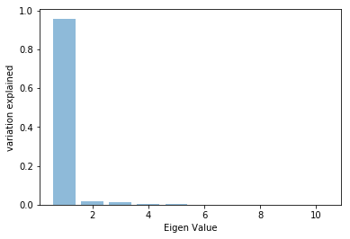

```python
plt.bar(list(range(1,11)), pca.explained_variance_ratio_, alpha = 0.5, align = 'center')
plt.ylabel('variation explained')
plt.xlabel('Eigen Value')
plt.show()
```

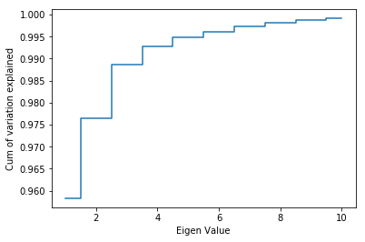

```python
plt.step(list(range(1,11)), np.cumsum(pca.explained_variance_ratio_), where = 'mid')
plt.ylabel('Cum of variation explained')
plt.xlabel('Eigen Value')
plt.show()
```

4.Performance Improvement:

A.Train another SVM on the components out of PCA. Tune the parameters to improve performance.

B.Share best Parameters observed from above step.

C.Print Classification metrics for train data of above model and share relative improvement in performance in all the models along with insights.

```python
pca7 = PCA(n_components=7)
pca7.fit(Xscaled)
print(np.round(pca7.components_,2),'\n')
print('The Eigen vectors','\n')
print(np.round(pca7.explained_variance_,2),'\n')
print('The Eigen values','\n')
Xpca7 = pca7.transform(Xscaled)
```

```
[[ 0.04  0.03  0.08  0.13  0.    0.    0.18 -0.04  0.01  0.06  0.16  0.94
   0.14 -0.    0.    0.01  0.    0.  ]
 [ 0.05 -0.02  0.11  0.86  0.24  0.08  0.01 -0.04 -0.   -0.06  0.17 -0.12
  -0.25 -0.1  -0.01  0.05  0.15  0.19]
 [-0.03  0.12  0.02  0.21  0.14  0.08  0.   -0.01 -0.    0.27  0.14 -0.2
   0.85  0.12  0.03 -0.17 -0.08 -0.07]
 [-0.17 -0.09 -0.27  0.    0.19  0.11 -0.04  0.03 -0.   -0.28  0.52 -0.01
  -0.14  0.5  -0.11  0.04 -0.25 -0.38]
 [-0.04  0.02  0.41 -0.12 -0.08  0.12  0.16 -0.03  0.01  0.14  0.24 -0.11
   0.06  0.01 -0.    0.81 -0.1   0.06]
 [ 0.13  0.11  0.33 -0.16 -0.01  0.27  0.13 -0.04  0.01  0.57  0.29 -0.07
  -0.35  0.11 -0.06 -0.43 -0.07  0.02]
 [-0.12  0.1  -0.2   0.17  0.27  0.13 -0.03  0.09  0.01  0.43 -0.6   0.1
  -0.16  0.23 -0.09  0.23 -0.29 -0.17]]

The Eigen vectors

[34861.63   663.73   444.43   144.49    74.65    48.98    44.05]

The Eigen values
```

```python
print(np.round(Xpca7,2))
```

```
[[ -56.78   13.28   24.33 ...    6.46    0.74   10.37]
 [-116.32   -9.66   -3.63 ...    8.8     6.2    -4.95]
 [ 212.09    8.83   17.89 ...   -1.73   -3.56   -5.06]
 ...
 [ 296.51   15.31   -8.43 ...  -14.14    9.63   11.74]
 [-180.73    2.58   -9.49 ...   11.68  -12.84   -3.02]
 [-247.04  -13.76  -16.37 ...    3.98   -4.13    5.26]]
```

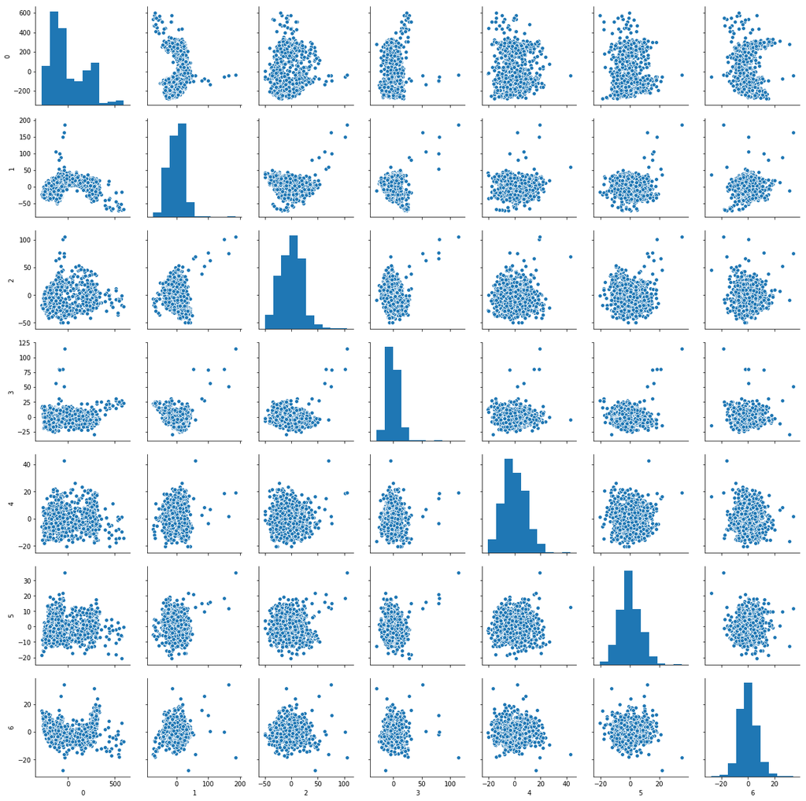

```python
sns.pairplot(pd.DataFrame(Xpca7));
```

```python
Xpca7_train, Xpca7_test, y_train, y_test = train_test_split(Xpca7,y, test_size=.3, random_state=42)

final_model_pca = SVC(gamma=0.01,C=10)

final_model_pca.fit(Xpca7_train,y_train)
final_model_pca.score(Xpca7_train,y_train)
```

```
1.0
```

```python
final_model_pca.score(Xpca7_test,y_test)
```

```
0.65748031496063
```

5.Data Understanding & Cleaning:

A.Explain pre-requisite/assumptions of PCA.

B.Explain advantages and limitations of PCA

Advantages of Principal Component Analysis

1. Removes Correlated Features: Reduce the number of features in your dataset.After implementing the PCA on your dataset, all the Principal Components are independent of one another. There is no correlation among them.
2. Improves Algorithm Performance: PCA is a very common way to speed up your Machine Learning algorithm by getting rid of correlated variables which don’t contribute in any decision making. The training time of the algorithms reduces significantly with less number of features.So, if the input dimensions are too high, then using PCA to speed up the algorithm is a reasonable choice.
3. Reduces Overfitting: Overfitting mainly occurs when there are too many variables in the dataset. So, PCA helps in overcoming the overfitting issue by reducing the number of features.
4. Improves Visualization: It is very hard to visualize and understand the data in high dimensions. PCA transforms a high dimensional data to low dimensional data (2 dimension) so that it can be visualized easily.

Disadvantages of Principal Component Analysis

1. Independent variables become less interpretable:After implementing PCA on the dataset, your original features will turn into Principal Components. Principal Components are the linear combination of your original features. Principal Components are not as readable and interpretable as original features.
1. Data standardization is must before PCA:You must standardize your data before implementing PCA, otherwise PCA will not be able to find the optimal Principal Components.Also, for standardization, all the categorical features are required to be converted into numerical features before PCA can be applied.